# 第13回 データの結合・絞り込み

プログラミング演習Ⅰ

佐藤 秀保

sato0035@toyo.jp

## 準備

1. [Posit Cloud](https://posit.cloud/)へ（日本語訳しないことを推奨）
2. 作成済みのプロジェクトをクリック
3. 先週使用のスクリプトをすべて閉じる
4. 新しくスクリプトを作成
5. 作成したスクリプトを保存：名前は「lec13」
6. ほうきボタンでオブジェクトを削除

授業中のコードはすべてスクリプトに書き実行すること

7. 先週のデータと必要パッケージを読込

```r
library(readxl)
library(tidyverse)
df <- read_excel("syokudo_data3.xlsx")
```

9. 先週の演習解答例を実行

```r
df_ensyuu <- df %>%
  filter(!is.na(総売上)) %>%
  mutate(客単価 = 総売上 / 客数) %>%
  mutate(総売上階級 = case_when(
    総売上 >= 1.1*mean(総売上) ~ 3,
    総売上 >= mean(総売上) ~ 2,
    総売上 >= 0.9*mean(総売上) ~ 1,
    TRUE ~ 0)
    ) %>%
  summarise(客単価平均 = mean(客単価),
            客数平均 = mean(客数),
            .by = "総売上階級"
            ) %>%
  arrange(総売上階級)
```

## さらにやりたいこと

- `df_ensyuu`で各総売上階級に何日分データがあったか知りたい
- ACEに別データとして
  - 「総売上階級」と
  - それらに何日分のデータがあるかを示す「観測数」

  の2列からなるデータフレーム「**obs**」がある
- `df_ensyuu`に「観測数」列を結合できないか？

### 結合のイメージ

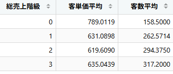

+

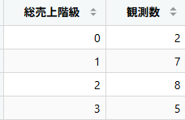

=

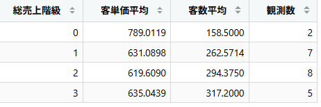

## データフレームの結合

- `dplyr`の**join系の関数**（データフレームを結合）
  - `left_join`関数
  - `right_join`関数
  - `inner_join`関数
  - `full_join`関数

### データフレームの結合における「キー」

- キー とは，**結合の際に2つのデータフレームを対応づけるための列**のこと
- 下図のオレンジ色がキー

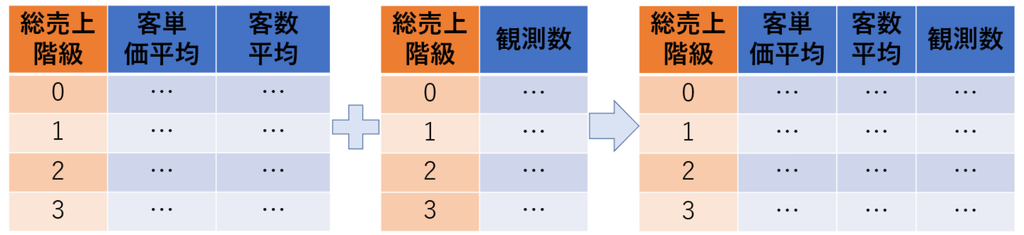

- 「キー」を頼りにすれば，結合するデータフレームの順番がめちゃくちゃでも問題なし

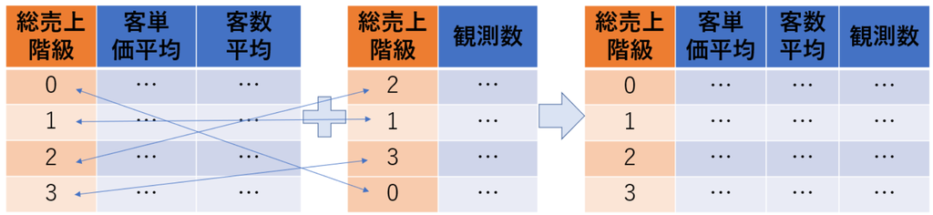

### left_join

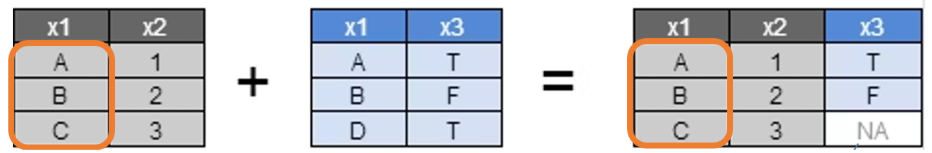

※以下画像は[このページ](https://qiita.com/matsuou1/items/b1bd9778610e3a586e71)より引用

**文法：left_join(左のデータフレーム，右のデータフレーム，by = “キー変数”)**

```r
#まずエクセルファイル「obs」を読み込む
obs <- read_excel("obs.xlsx")

#結合
df1 <- df_ensyuu %>%
  left_join(obs, by = "総売上階級")
```

### right_join

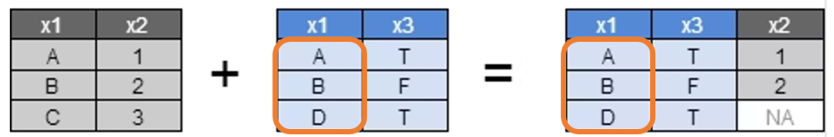

### inner_join

- **双方の**データフレームに存在するキーの行を返す
  - 双方のデータフレームに存在しないキーの行は削除

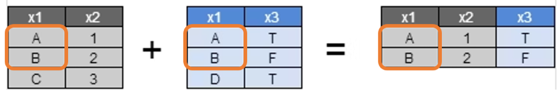

## データフレームの絞り込み

- `dplyr`の**join系の関数**（データフレームを絞り込み）
  - `semi_join`関数
  - `anti_join`関数

### semi_join

- 結合ではなく絞り込み
- 左のデータフレームから，キーが右のデータフレームにも存在する行を絞り込む

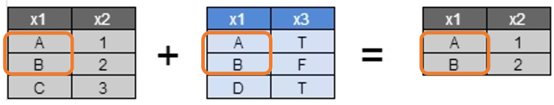

### anti_join

- 結合ではなく絞り込み
- 左のデータフレームから，キーが右のデータフレームに存在しない行を絞り込む

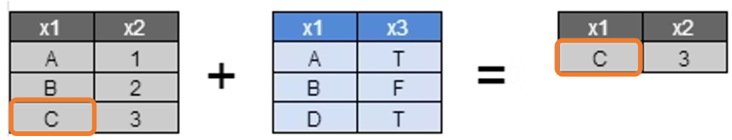

## 演習

1. Aceの`weather_saitama`というエクセルファイルをアップロードして`weather`という名前で保存
2. 「日付」をキーとして`df`と`weatherを`結合し`df_combined`として保存
3. 「降水量合計」が`0`より大きい場合に`1`，それ以外の場合には`0`をとる「雨天ダミー」変数を作成
4. 「雨天ダミー」の値ごとの「総売上」の平均値を計算したデータフレーム`df_ame`を作成

## 課題

- ACEの小テスト：「第13回」
- ACEのレポート：「第13回」
  - ローカルに保存したlec13.Rを提出